fossil

# Drug and target, matched again.

The paper's code is gone, so we wrote the method again from its text and ran it on the data it used. 2 of the 19 results are exact and 6 agree. Fig. 1 came back on all four networks, and the ten nuclear receptor predictions of Table 5 came back in almost the same order. Three settings the paper never printed had to be found first.

See every result

## Fig. 1a

Fig. 1a. Precision against recall on the enzyme network: BLMd solid, BLMt dashed, the two aggregated dotted.

Agrees

Published

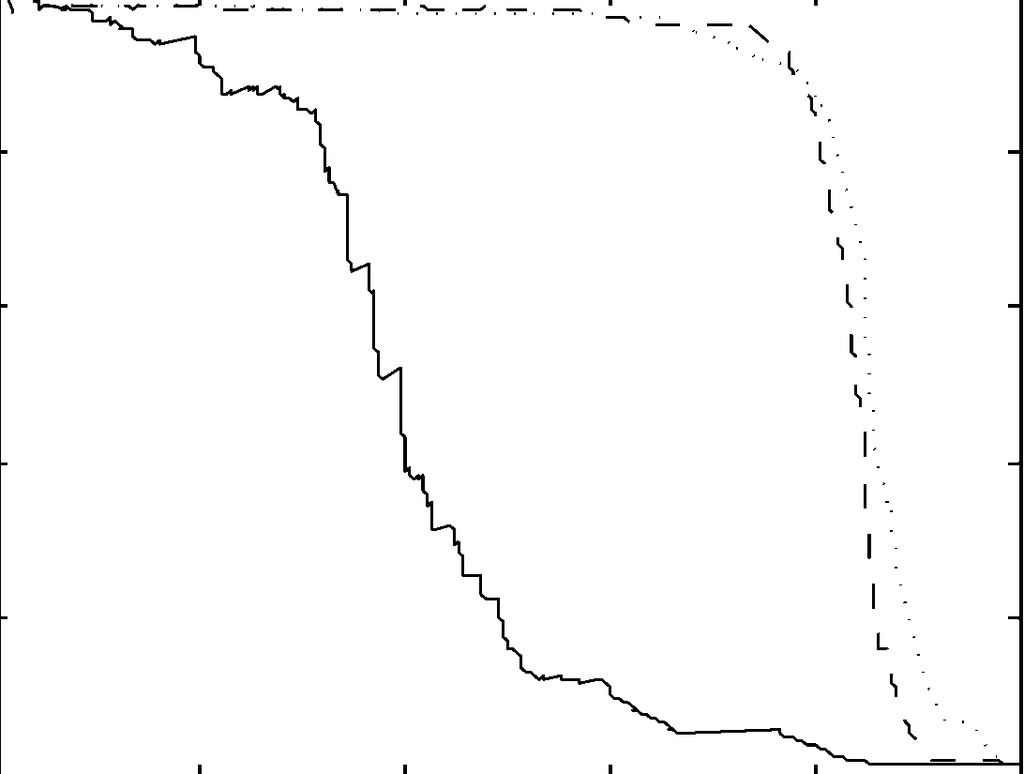

Our run

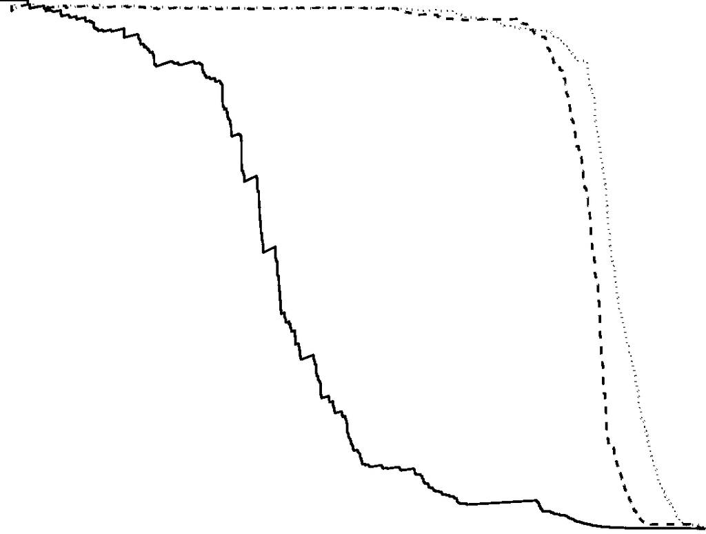

**Pixels**

48.2% within 2 px

**m(BLMd,BLMt): precision points within 0.01**

paper 20, ours 15

**BLMd: precision points within 0.01**

paper 20, ours 19

**BLMt: precision points within 0.01**

paper 20, ours 18

The curves agree where it can be measured: the published precision is within 0.01 of ours at most grid points (enzyme panel: BLMd 19 of 20 grid points, BLMt 18, the aggregate 15), while another dataset's curves on the same panel reach at most 6 of 20. The pixel score sits near 50 per cent because two of the three curves are dashed and the phase of the dashes, which the PDF does not fix to the data, decides where ink falls inside a line.

## Fig. 1b

Fig. 1b. The same three curves on the ion channel network.

Agrees

Published

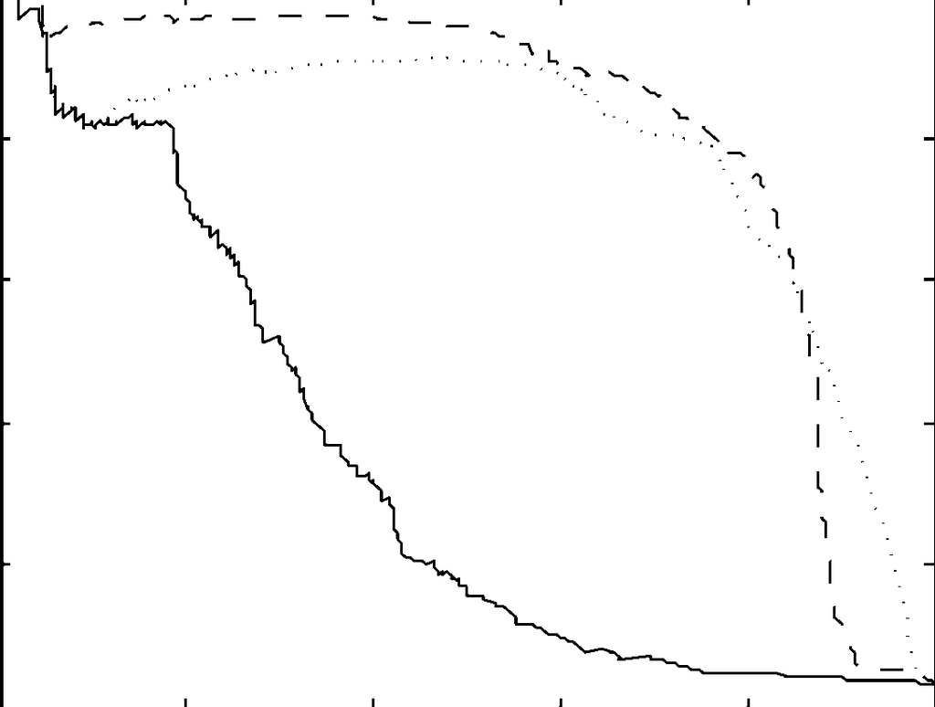

Our run

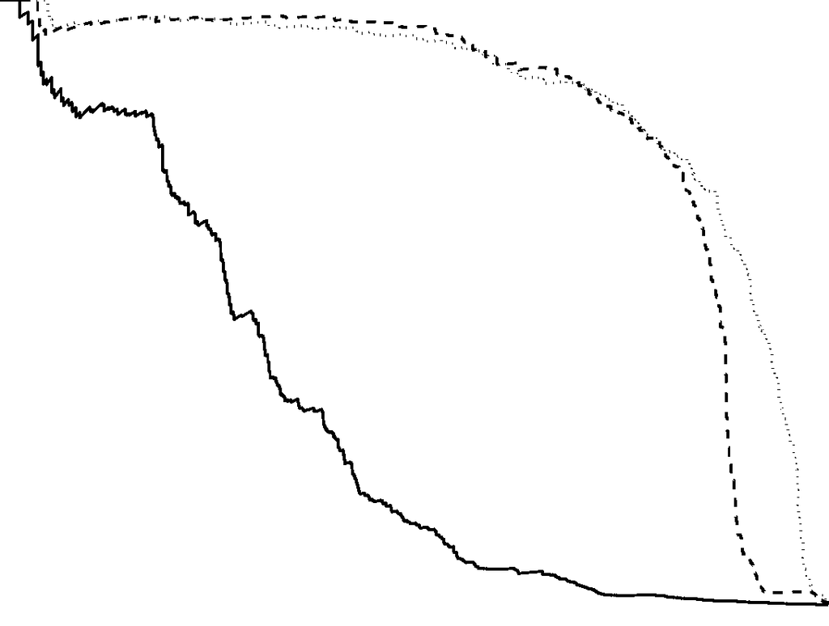

**Pixels**

47.7% within 2 px

**m(BLMd,BLMt): precision points within 0.01**

paper 20, ours 1

**BLMd: precision points within 0.01**

paper 20, ours 15

**BLMt: precision points within 0.01**

paper 20, ours 18

The curves agree where it can be measured: the published precision is within 0.01 of ours at most grid points (ion channel panel: BLMd 15 of 20 grid points, BLMt 18, the aggregate 1), while another dataset's curves on the same panel reach at most 6 of 20. The pixel score sits near 50 per cent because two of the three curves are dashed and the phase of the dashes, which the PDF does not fix to the data, decides where ink falls inside a line. The aggregate curve is the one that differs: in the published panel it follows BLMd at the top of the ranking and in ours it follows BLMt, which is the same scale question as the aggregated rows of Table 2, and the reason the curves were put on one scale before the maximum.

## Fig. 1c

Fig. 1c. The same three curves on the GPCR network.

Agrees

Published

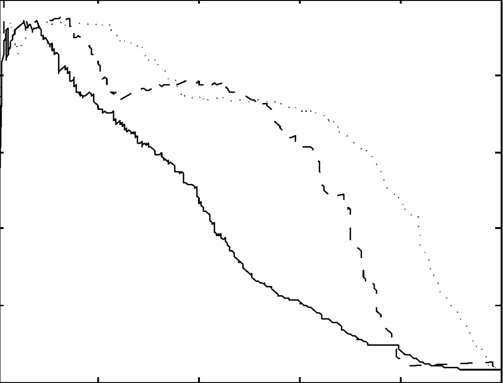

Our run

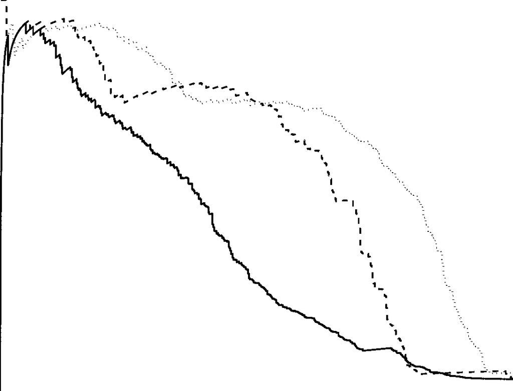

**Pixels**

44.9% within 2 px

**m(BLMd,BLMt): precision points within 0.01**

paper 20, ours 11

**BLMd: precision points within 0.01**

paper 20, ours 15

**BLMt: precision points within 0.01**

paper 20, ours 17

The curves agree where it can be measured: the published precision is within 0.01 of ours at most grid points (GPCR panel: BLMd 15 of 20 grid points, BLMt 17, the aggregate 11), while another dataset's curves on the same panel reach at most 6 of 20. The pixel score sits near 50 per cent because two of the three curves are dashed and the phase of the dashes, which the PDF does not fix to the data, decides where ink falls inside a line.

## Fig. 1d

Fig. 1d. The same three curves on the nuclear receptor network.

Agrees

Published

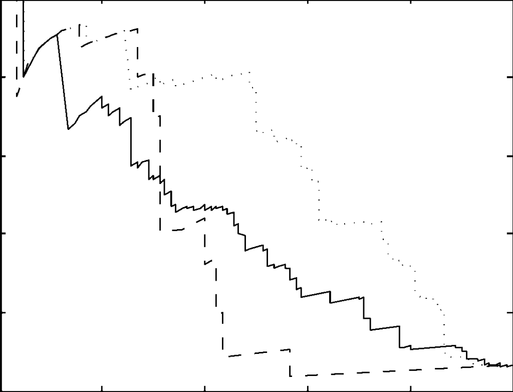

Our run

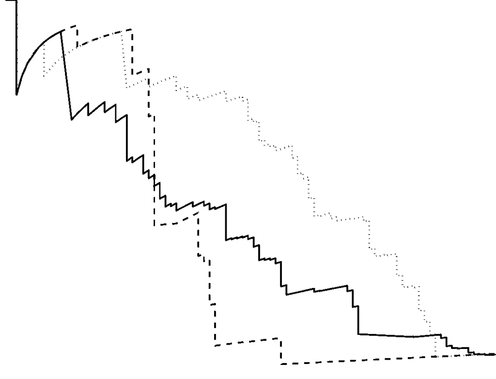

**Pixels**

51.2% within 2 px

**m(BLMd,BLMt): precision points within 0.01**

paper 20, ours 9

**BLMd: precision points within 0.01**

paper 20, ours 7

**BLMt: precision points within 0.01**

paper 20, ours 15

## Fig. 2

Fig. 2. Part of the predicted nuclear receptor network. Circles are drugs, squares are target proteins, solid edges are known interactions and dashed edges are top predictions. The published layout is drawn by hand, so ours places the same nodes on a circle.

Partly agrees

Published

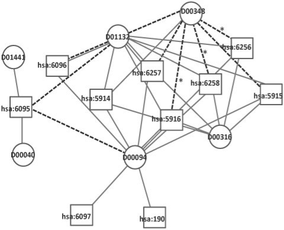

Our run

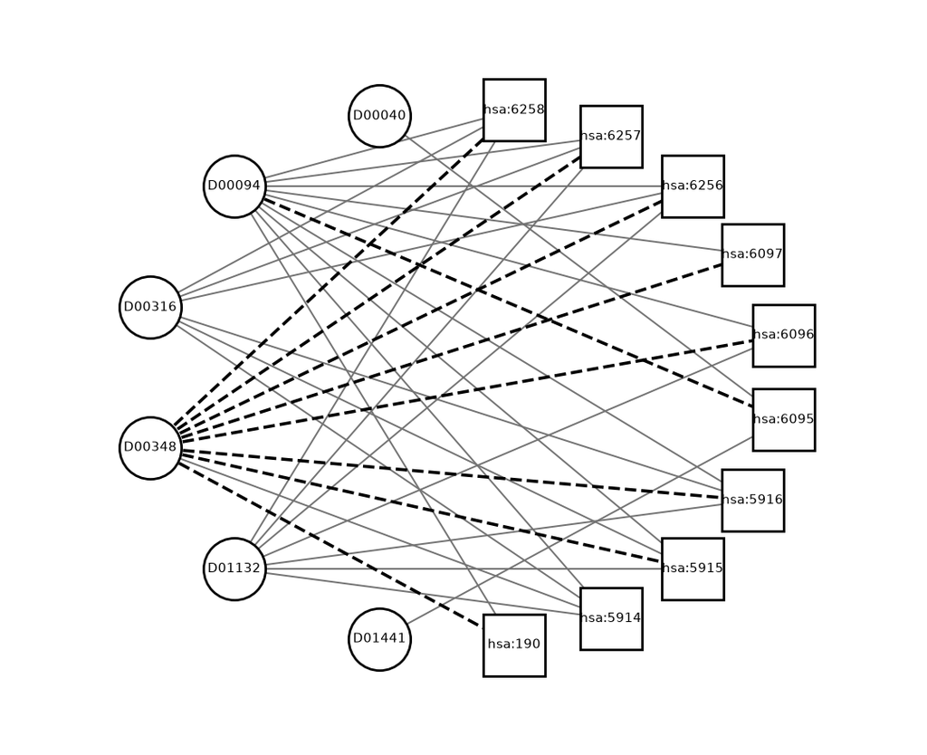

**D00094-hsa:6095 is in our top 20**

paper yes, ours yes

**D00348-hsa:5915 is in our top 20**

paper yes, ours yes

**D00348-hsa:5916 is in our top 20**

paper yes, ours yes

**D00348-hsa:6256 is in our top 20**

paper yes, ours yes

**D00348-hsa:6258 is in our top 20**

paper yes, ours yes

**D00348-hsa:6096 is in our top 20**

paper yes, ours yes

**D01132-hsa:6095 is in our top 20**

paper yes, ours no

**drug nodes drawn**

paper 6, ours 6

**target nodes drawn**

paper 10, ours 10

Six of the seven dashed edges of the published figure are in our top 20, at ranks 2, 3, 4, 5, 7 and 13. The seventh, D01132 with hsa:6095, is our rank 23. The caption says the dashed edges are some of the 20 highest scoring predictions, so a pair just outside our top 20 is the same kind of near miss as the rank swaps of Table 5.

## Table 1, enzyme

Leave-one-out AUC and AUPR of the twelve methods, as printed and as our run gives them. A star marks the AUCs the paper copies from Yamanishi et al. (2008).

Partly agrees

| Method | AUC, paper | AUC, ours | AUPR, paper | AUPR, ours |
| --- | --- | --- | --- | --- |
| KRMd* | 82.8 | **83.3** | 38.7 | **35.0** |
| BLMd | 83.1 | **82.8** | 40.6 | **40.6** |
| m(KRMd,BLMd) | 86.9 | **87.2** | 39.4 | **39.0** |
| KRMt* | 92.9 | **93.2** | 80.6 | **78.3** |
| BLMt | 94.2 | **94.2** | 82.3 | **82.3** |
| m(KRMt,BLMt) | 94.4 | **94.4** | 80.7 | **79.9** |
| m(KRMd,KRMt) | 96.7 | **96.6** | 83.1 | **81.6** |
| m(BLMd,BLMt) | 97.3 | **97.3** | 84.1 | **84.2** |
| m(KRMd,KRMt,BLMd,BLMt) | 97.6 | **97.6** | 83.3 | **83.8** |
| NNd | 68.2 | **68.2** | 33.5 | **33.4** |
| NNt | 89.9 | **89.9** | 76.9 | **76.9** |
| m(NNd,NNt) | 93.0 | **93.0** | 63.8 | **63.8** |

11 of 24 values. 11 of the 24 printed values come back to the digit and 21 are within one point. The largest gaps are the KRM AUPRs (KRMd 35.0 against 38.7, KRMt 78.3 against 80.6): the AUCs the paper stars for those rows are copied from Yamanishi et al. (2008), where they came from 10-fold cross-validation, so their leave-one-out AUPR cannot be checked against the same run. Three settings the paper does not give were identified against its own values and are listed as assumptions.

## Table 2, ion channel

Leave-one-out AUC and AUPR of the twelve methods, as printed and as our run gives them. A star marks the AUCs the paper copies from Yamanishi et al. (2008).

Partly agrees

| Method | AUC, paper | AUC, ours | AUPR, paper | AUPR, ours |
| --- | --- | --- | --- | --- |
| KRMd* | 74.5 | **74.7** | 33.7 | **29.5** |
| BLMd | 74.5 | **74.0** | 33.0 | **32.7** |
| m(KRMd,BLMd) | 73.9 | **74.8** | 33.9 | **31.9** |
| KRMt* | 91.7 | **91.7** | 79.6 | **76.9** |
| BLMt | 93.5 | **93.5** | 80.9 | **80.9** |
| m(KRMt,BLMt) | 93.5 | **93.4** | 81.3 | **80.0** |
| m(KRMd,KRMt) | 96.9 | **96.7** | 77.8 | **73.3** |
| m(BLMd,BLMt) | 97.0 | **96.9** | 77.9 | **78.1** |
| m(KRMd,KRMt,BLMd,BLMt) | 97.3 | **97.3** | 78.1 | **76.9** |
| NNd | 64.7 | **64.6** | 22.9 | **22.6** |
| NNt | 88.7 | **88.7** | 72.8 | **72.7** |
| m(NNd,NNt) | 91.7 | **91.7** | 53.8 | **53.6** |

## Table 3, GPCR

Leave-one-out AUC and AUPR of the twelve methods, as printed and as our run gives them. A star marks the AUCs the paper copies from Yamanishi et al. (2008).

Partly agrees

| Method | AUC, paper | AUC, ours | AUPR, paper | AUPR, ours |
| --- | --- | --- | --- | --- |
| KRMd* | 87.3 | **86.8** | 40.5 | **39.9** |
| BLMd | 82.3 | **81.5** | 38.8 | **38.2** |
| m(KRMd,BLMd) | 88.2 | **87.9** | 41.4 | **40.7** |
| KRMt* | 82.8 | **84.2** | 57.7 | **57.5** |
| BLMt | 87.2 | **87.2** | 56.9 | **56.9** |
| m(KRMt,BLMt) | 86.7 | **87.0** | 57.4 | **58.7** |
| m(KRMd,KRMt) | 94.7 | **95.1** | 66.4 | **65.4** |
| m(BLMd,BLMt) | 95.3 | **95.1** | 66.7 | **66.6** |
| m(KRMd,KRMt,BLMd,BLMt) | 95.5 | **95.7** | 66.7 | **67.5** |
| NNd | 69.5 | **69.5** | 32.5 | **32.5** |
| NNt | 81.2 | **81.2** | 52.1 | **52.1** |
| m(NNd,NNt) | 88.5 | **88.5** | 48.5 | **48.5** |

8 of 24 values. 8 of the 24 printed values come back to the digit and 22 are within one point; no value is more than 1.4 away. The largest gap is KRMt's AUC, 84.2 against 82.8, a row whose printed AUC is copied from Yamanishi et al. (2008).

## Table 4, nuclear receptor

Leave-one-out AUC and AUPR of the twelve methods, as printed and as our run gives them. A star marks the AUCs the paper copies from Yamanishi et al. (2008).

Partly agrees

| Method | AUC, paper | AUC, ours | AUPR, paper | AUPR, ours |
| --- | --- | --- | --- | --- |
| KRMd* | 83.6 | **83.5** | 43.6 | **39.2** |
| BLMd | 81.2 | **80.3** | 41.3 | **40.7** |
| m(KRMd,BLMd) | 85.4 | **85.0** | 45.0 | **43.3** |
| KRMt* | 52.3 | **55.0** | 36.2 | **35.4** |
| BLMt | 53.6 | **53.7** | 35.8 | **35.8** |
| m(KRMt,BLMt) | 53.6 | **53.9** | 36.0 | **34.8** |
| m(KRMd,KRMt) | 86.7 | **86.8** | 61.0 | **57.8** |
| m(BLMd,BLMt) | 85.8 | **86.0** | 60.0 | **60.0** |
| m(KRMd,KRMt,BLMd,BLMt) | 88.1 | **88.3** | 61.2 | **59.5** |
| NNd | 73.3 | **73.3** | 40.5 | **38.5** |
| NNt | 68.7 | **68.7** | 42.3 | **41.8** |
| m(NNd,NNt) | 85.1 | **85.2** | 53.6 | **53.1** |

## Table 5

The ten highest scoring nuclear receptor pairs that were not known interactions, and where our run ranks each of them.

Partly agrees

| Rank in the paper | Pair | Rank in our run |
| --- | --- | --- |
| 1 | D00094 / hsa:6095 | 2 |
| 2 | D00182 / hsa:2099 | 1 |
| 3 | D00348 / hsa:5915 | 3 |
| 4 | D00348 / hsa:5916 | 4 |
| 5 | D00348 / hsa:6256 | 5 |
| 6 | D00348 / hsa:6257 | 6 |
| 7 | D00348 / hsa:6258 | 7 |
| 8 | D00094 / hsa:3174 | 9 |
| 9 | D00690 / hsa:2908 | 10 |
| 10 | D00075 / hsa:5241 | 8 |

All ten pairs of the paper's Table 5 are in our top ten, and the five pairs of the Isotretinoin block come out in the paper's own order. Five sit at a different rank: our ranks 1 and 2 are the paper's 2 and 1, and its ranks 8, 9 and 10 are our 9, 10 and 8. Those five pairs are separated by at most 0.08 of a score unit, and the five Isotretinoin pairs are exactly tied at 0.194683 because they come from one local model, so their printed order is a tie break the paper does not state.

## Every result

Every figure, table and statement of the paper. The verdicts are computed from the numbers by check_results.py; none of them is typed by hand.

Result

Verdict

Measure

Why

Table 1, enzyme dataset

Partly agrees

11 of 24 values

11 of the 24 printed values come back to the digit and 21 are within one point. The largest gaps are the KRM AUPRs (KRMd 35.0 against 38.7, KRMt 78.3 against 80.6): the AUCs the paper stars for those rows are copied from Yamanishi et al. (2008), where they came from 10-fold cross-validation, so their leave-one-out AUPR cannot be checked against the same run. Three settings the paper does not give were identified against its own values and are listed as assumptions.

Table 2, ion channel dataset

Partly agrees

6 of 24 values

Table 3, GPCR dataset

Partly agrees

8 of 24 values

8 of the 24 printed values come back to the digit and 22 are within one point; no value is more than 1.4 away. The largest gap is KRMt's AUC, 84.2 against 82.8, a row whose printed AUC is copied from Yamanishi et al. (2008).

Table 4, nuclear receptor dataset

Partly agrees

4 of 24 values

Fig. 1a, enzyme precision-recall curves

Agrees

48.2% within 2 px

The curves agree where it can be measured: the published precision is within 0.01 of ours at most grid points (enzyme panel: BLMd 19 of 20 grid points, BLMt 18, the aggregate 15), while another dataset's curves on the same panel reach at most 6 of 20. The pixel score sits near 50 per cent because two of the three curves are dashed and the phase of the dashes, which the PDF does not fix to the data, decides where ink falls inside a line.

Fig. 1b, ion channel precision-recall curves

Agrees

47.7% within 2 px

The curves agree where it can be measured: the published precision is within 0.01 of ours at most grid points (ion channel panel: BLMd 15 of 20 grid points, BLMt 18, the aggregate 1), while another dataset's curves on the same panel reach at most 6 of 20. The pixel score sits near 50 per cent because two of the three curves are dashed and the phase of the dashes, which the PDF does not fix to the data, decides where ink falls inside a line. The aggregate curve is the one that differs: in the published panel it follows BLMd at the top of the ranking and in ours it follows BLMt, which is the same scale question as the aggregated rows of Table 2, and the reason the curves were put on one scale before the maximum.

Fig. 1c, GPCR precision-recall curves

Agrees

44.9% within 2 px

The curves agree where it can be measured: the published precision is within 0.01 of ours at most grid points (GPCR panel: BLMd 15 of 20 grid points, BLMt 17, the aggregate 11), while another dataset's curves on the same panel reach at most 6 of 20. The pixel score sits near 50 per cent because two of the three curves are dashed and the phase of the dashes, which the PDF does not fix to the data, decides where ink falls inside a line.

Fig. 1d, nuclear receptor precision-recall curves

Agrees

51.2% within 2 px

Table 5, top 10 predicted nuclear receptor pairs

Partly agrees

1 of 2 values

- pairs of the paper's top 10 that are in our top 10: paper 10, ours **10**
- pairs at the same rank: paper 10, ours **5**

All ten pairs of the paper's Table 5 are in our top ten, and the five pairs of the Isotretinoin block come out in the paper's own order. Five sit at a different rank: our ranks 1 and 2 are the paper's 2 and 1, and its ranks 8, 9 and 10 are our 9, 10 and 8. Those five pairs are separated by at most 0.08 of a score unit, and the five Isotretinoin pairs are exactly tied at 0.194683 because they come from one local model, so their printed order is a tie break the paper does not state.

Fig. 2, part of the predicted nuclear receptor network

Partly agrees

8 of 9 values

- D00094-hsa:6095 is in our top 20: paper yes, ours **yes**
- D00348-hsa:5915 is in our top 20: paper yes, ours **yes**
- D00348-hsa:5916 is in our top 20: paper yes, ours **yes**
- D00348-hsa:6256 is in our top 20: paper yes, ours **yes**
- D00348-hsa:6258 is in our top 20: paper yes, ours **yes**
- D00348-hsa:6096 is in our top 20: paper yes, ours **yes**
- D01132-hsa:6095 is in our top 20: paper yes, ours **no**
- drug nodes drawn: paper 6, ours **6**
- target nodes drawn: paper 10, ours **10**

Six of the seven dashed edges of the published figure are in our top 20, at ranks 2, 3, 4, 5, 7 and 13. The seventh, D01132 with hsa:6095, is our rank 23. The caption says the dashed edges are some of the 20 highest scoring predictions, so a pair just outside our top 20 is the same kind of near miss as the rank swaps of Table 5.

The statements of Section 4, recomputed from the paper's own tables

Agrees

passed

Section 4.4, the best AUC passes from 92.9 to 97.6, 91.7 to 97.3, 87.3 to 95.5 and 83.6 to 88.1

Partly agrees

3 of 8 values

- best_auc_krm_e: paper 92.9, ours **93.2**
- best_auc_new_e: paper 97.6, ours **97.6**
- best_auc_krm_ic: paper 91.7, ours **91.7**
- best_auc_new_ic: paper 97.3, ours **97.3**
- best_auc_krm_gpcr: paper 87.3, ours **86.8**
- best_auc_new_gpcr: paper 95.5, ours **95.7**
- best_auc_krm_nr: paper 83.6, ours **83.5**
- best_auc_new_nr: paper 88.1, ours **88.3**

Section 4.4, the best AUPR passes from 80.6 to 84.1, 79.6 to 81.3, 57.7 to 66.7 and 43.6 to 61.2

Differs

0 of 8 values

- best_aupr_krm_e: paper 80.6, ours **78.3**
- best_aupr_new_e: paper 84.1, ours **84.2**
- best_aupr_krm_ic: paper 79.6, ours **76.9**
- best_aupr_new_ic: paper 81.3, ours **80.9**
- best_aupr_krm_gpcr: paper 57.7, ours **57.5**
- best_aupr_new_gpcr: paper 66.7, ours **67.5**
- best_aupr_krm_nr: paper 43.6, ours **39.2**
- best_aupr_new_nr: paper 61.2, ours **60.0**

Sections 4.1 to 4.3, how many of the eight conditions the local models win

Partly agrees

1 of 3 values

- new_drug_conditions_won_by_blm: paper 7, ours **8**
- new_target_conditions_won_by_blm: paper 6, ours **7**
- aggregated_conditions_won_by_blm_aggregation: paper 8, ours **8**

Two of the three counts are one higher in our run: eight of eight conditions instead of seven in Section 4.1 and seven instead of six in Section 4.2. Both differences come from values that tie in the paper and separate here. The paper's seven of eight needs its ion channel AUC tie (KRMd and BLMd both 74.5) to count against the local models; our run gives 74.7 and 74.0, so the tie is gone. In Section 4.2 the paper's own tables give six only when the nearest-neighbour row is left out of the comparison, which is how this check reads it.

Section 1, nearly 90% precision at 60% recall on the ion channel dataset

Exact

2 of 2 values

- precision at 60% recall is nearly 90%: paper yes, ours **yes**
- precision at 60% recall, read from the published curve and from ours: paper 0.9, ours **0.91**

Section 2.1, the drugs, targets and interactions of each dataset

Exact

12 of 12 values

- enzyme drugs: paper 445, ours **445**
- enzyme targets: paper 664, ours **664**
- enzyme interactions: paper 2926, ours **2926**
- ion channel drugs: paper 210, ours **210**
- ion channel targets: paper 204, ours **204**
- ion channel interactions: paper 1476, ours **1476**
- GPCR drugs: paper 223, ours **223**
- GPCR targets: paper 95, ours **95**
- GPCR interactions: paper 635, ours **635**
- nuclear receptor drugs: paper 54, ours **54**
- nuclear receptor targets: paper 26, ours **26**
- nuclear receptor interactions: paper 90, ours **90**

Sections 4.5 and 5, at least 4 of the top 10 nuclear receptor predictions were later confirmed

Not attempted

The confirmation status is a lookup in the SuperTarget database as of January 2009 and a literature search, not a computation. SuperTarget has been superseded and no January 2009 release is archived, so the status of the ten pairs cannot be recovered as the paper found it. Our run ranks the same ten pairs first, which is the part of the claim the method decides.

The authors' implementation against this one

Not attempted

The authors' MATLAB implementation is lost. The paper offers it on request and links a project page, which is now a redirect to the laboratory's home page; the Wayback Machine holds the page from 2014 and 2015, which lists bipartiteLocalModel.m and a data archive, but no capture of either file, and no copy is on GitHub. The method is therefore written from the paper's text and checked against its printed values.

Python package blmdti and its tutorial

Agrees

passed

The main claim of the paper holds: on all four networks the best score of its own methods beats the kernel regression method it compares with. The headline AUCs come back at 97.6, 97.3, 95.7 and 88.3 against the printed 97.6, 97.3, 95.5 and 88.1. The counts in Sections 4.1 and 4.2 are one higher in our run, because values that tie in the paper separate here.

## What came back

**Fig. 1, all four networks**

**The dataset**

445, 210, 223 and 54 drugs; 664, 204, 95 and 26 targets; 2926, 1476, 635 and 90 interactions. Every count exact.

**Table 5**

All ten predicted nuclear receptor pairs, in our top ten; five at the same rank, the five tied ones in the paper's order.

**The method**

As a Python package, blmdti, with its tutorial.

## What stayed buried

The main claim of the paper holds: on all four networks the best score of its own methods beats the kernel regression method it compares with. The headline AUCs come back at 97.6, 97.3, 95.7 and 88.3 against the printed 97.6, 97.3, 95.5 and 88.1. The counts in Sections 4.1 and 4.2 are one higher in our run, because values that tie in the paper separate here.

## What we matched

The paper reports 96 numbers in its four tables. We ran the method on the same data and compared every one of them.

**Exact at the printed digit**

29 of 96 values

**Within half a point**

67 of 96

**Within one point**

78 of 96

**Largest difference**

4.5 points, on an AUPR of the comparison method

**Fig. 1 panels**

Four of four, each above its controls

**Settings found by search**

Three, each with its sensitivity on the page